# 01.01.03.00.Aplicaciones.AgujerosNegros.Geodesicas

Indice | Previo: Aplicaciones.AgujerosNegros.FenomenologiaBasica | Siguiente: Aplicaciones.AgujerosNegros.Coordenadas

### 1.1.1. Movimiento geodésico en la métrica de Schwarzschild

La verdadera experiencia extrema en un agujero negro la siente un observador que cae libremente.

Para describir esta exepriencia necesitamos estudiar el movimiento geodésico en la métrica. Antes habíamos escrito las ecuaciones geodésicas:

\begin{eqnarray} \nonumber \dot{U}_T & = & -\frac{R_S}{r^2}\frac{1}{1-R_S/r}U_T U_r\\ \nonumber \dot{U}_r & = & -\frac{R_S}{2r^2}\left(1-\frac{R_S}{r}\right)U_T^2+\\ \nonumber & & +\frac{R_S}{2r^2}\frac{1}{1-R_S/r}U_r^2 +\\ \nonumber & & +\left(1-\frac{R_S}{r}\right) r U_\theta^2 +\\ \nonumber & & +\left(1-\frac{R_S}{r}\right) r \sin^2\theta U_\varphi^2\\ \nonumber \dot{U}_\theta & = & -\frac{2}{r}U_r U_\theta+\cos\theta\sin\theta\;U_\varphi^2\\ \nonumber \dot{U}_\varphi & = & -\frac{2}{r}U_r U_\varphi-2\cot\theta\;U_\theta U_\varphi\\ \end{eqnarray}

donde $U_\mu\equiv\mathrm{d}x^\mu/\mathrm{d}\sigma$ y $\sigma$ es un parámetro conforme (tiempo propio $\tau$ en el caso de una partícula con masa y $\lambda$ en el caso de una partícula sin masa).

Es claro que una solución analítica a estas ecuaciones en toda su generalidad no es posible. Sin embargo es posible estudiar el comportamiento de estas ecuaciones encontrando las constantes de movimiento.

### 1.1.11. Constantes de movimiento

En el caso por ejemplo de una partícula con masa $m$ sabemos que una constante de movimiento esta dada por el módulo de la cuadrivelocidad:

$$ g_{\mu\nu}U^\mu U^\nu=c^2 $$

Que se puede escribir explícitamente como:

$$ \left(1-\frac{R_S}{r}\right)\left(\frac{\mathrm{d} t}{\mathrm{d} \tau}\right)^{2}-\left(1-\frac{R_S}{r}\right)^{-1}\left(\frac{\mathrm{d} r}{\mathrm{d} \tau}\right)^{2}-\left(\frac{\mathrm{d}\ell}{\mathrm{d} \tau}\right)^{2}=c^2 $$

donde $\mathrm{d}\ell^2=r^2\mathrm{d}\theta^2+r^2\sin^2\theta \mathrm{d}\phi^2$.

La métrica tiene dos vectores de Killing: el correspondiente al tiempo $\xi_t:(1,0,0,0)$ y el que corresponde a la coordenada angular $\phi$, $\xi_\phi:(0,0,0,1)$. Habíamos visto que esto implica que las ccantidades:

$$ g_{\mu\nu}\xi^\mu U^\nu $$

son también constantes.

Asociada con la simetría temporal (que viene del hecho que la métrica es estática) tenemos la constante:

$$ \left(1-\frac{R_S}{r}\right)\left(\frac{\mathrm{d} t}{\mathrm{d} \tau}\right)={\cal E} $$

¿Qué es la cantidad ${\cal E}$? Clásicamente sabemos que la simetría temporal esta asociada con la energía. Es por eso que hemos llamado a esta cantidad con este nombre. Pero ¿es realmente ${\cal E}$ una energía. Para entender lo que esta cantidad representa, consideremos el caso en el que tenemos la partícula moviéndose con una velocidad $v$ a una distancia $r\gg R_S$. En este caso la cuadratura queda:

$$ {\cal E}=\lim_{r\rightarrow \infty}\left(1-\frac{R_S}{r}\right)\left(\frac{\mathrm{d} t}{\mathrm{d} \tau}\right)=\frac{\mathrm{d} t}{\mathrm{d} \tau} $$

Dado que el espacio es plano a una gran distancia $\mathrm{d}t/\mathrm{d}\tau=\gamma_v$, es decir la constante se aproxima al valor del factor de Lorentz-Einstein de la partícula en el infinito. ¿Qué significa esto y que relación guarda con la energía?. En el espacio tiempo plano:

$$ E=\gamma_v m c^2 $$

donde $E$ es la energía total de la partícula. Pero esta definición solo es válida en el espacio plano en el infinito. Si llamamos $E_\infty=\gamma_\infty m c^2$ a la energía que tendría la partícula cuando esta muy lejos ($\gamma_\infty$ es el factor gamma asociado a la velocidad de la partícula cuando esta muy lejos de la fuente), podemos escribir la constante ${\cal E}$ como:

$$ {\cal E}=\frac{E_\infty}{mc^2} $$

De este modo la cuadratura asociada con la simetría temporal será:

$$ \left(1-\frac{R_S}{r}\right)\left(\frac{\mathrm{d} t}{\mathrm{d} \tau}\right)=\frac{E_\infty}{mc^2} $$

Por su lado la cuadratura asociada con el vector de Killing de la coordenada angular $\phi$ será:

$$ r^2\sin^2\theta\left(\frac{\mathrm{d} \phi}{\mathrm{d} \tau}\right)=J_z $$

¿Que implica esta constante de movimiento?. Imaginemos una situación en la que el movimiento se realiza tal que $J_z=0$. Esto implicara que $\mathrm{d}\phi/\mathrm{d}\tau=0$. Es decir, la partícula se mueve sin cambiar su coordenada angular $\phi$, que es lo mismo que moverse sobre el plano con $\phi=\mathrm{cte}$. Es decir, la ecuación anterior implica que escogida adecuadamente la dirección del sistema de coordenadas el movimiento se realizará sobre un plano. Un cambio del sistema de coordenadas no modifica esta condición. De modo que podemos decir que este resultado muestra que el movimiento de caída libre en la métrica de Shcwarzschild se realiza siempre sobre un plano, como sucede también en el caso newtoniano.

Si fijamos la dirección de los ejes coordenados de modo que el plano $x-y$ coincida con el plano de la geodésica, la constante anterior se simplifica y se convierte en:

$$ r^2\dot\phi=J_z $$

donde, muy lejos de la fuente, reconocemos claramente la magnitud del momento angular $L_\infty=m r^2\dot\phi$.

La cuadratura anterior se puede escribir entonces como:

$$ r^2\left(\frac{\mathrm{d} \phi}{\mathrm{d} \tau}\right)=\frac{L_\infty}{m} $$

### 1.1.12. Caída libre en un agujero negro

Una encontradas las 3 cuadraturas básicas del movimiento geodésico:

\begin{eqnarray} \left(1-\frac{R_S}{r}\right)\left(\frac{\mathrm{d} t}{\mathrm{d} \tau}\right)^{2}-\left(1-\frac{R_S}{r}\right)^{-1}\left(\frac{\mathrm{d} r}{\mathrm{d} \tau}\right)^{2}-\left(\frac{\mathrm{d}\ell}{\mathrm{d} \tau}\right)^{2} & = & c^2\\ \left(1-\frac{R_S}{r}\right)\left(\frac{\mathrm{d} t}{\mathrm{d} \tau}\right) & = & \frac{E_\infty}{mc^2}\\ r^2\left(\frac{\mathrm{d} \phi}{\mathrm{d} \tau}\right) & = & \frac{L_\infty}{m} \end{eqnarray}

podemos intentar analizar (incluso resolver en situaciones particulares) el movimiento geodésico en la métrica de Scwahrzschild usando estas cuadraturas.

Podemos reemplazar las dos últimas constantes de movimiento en la primera ecuación para obtener una ecuación diferencial solo para la coordenada radial $r$:

$$ \left(\frac{\mathrm{d} r}{\mathrm{d} \tau}\right)^{2}+\frac{L_\infty^{2}}{m^{2} r^{2}}\left(1-\frac{R_S}{r}\right)=c^{2}\left[\left(\frac{E_\infty}{m c^{2}}\right)^{2}-1+\frac{R_S}{r}\right] $$

La caída libre corresponde a la condición inicial $L_\infty=0$. En este caso la ecuación de movimiento se escribe como:

$$ \left(\frac{\mathrm{d} r}{\mathrm{d} \tau}\right)^{2}=c^{2}\left[\left(\frac{E_\infty}{m c^{2}}\right)^{2}-1+\frac{R_S}{r}\right] $$

**Nota: Límite Newtoniano.** Si derivamos respecto al tiempo, obtenemos:

> $$ 2\left(\frac{\mathrm{d} r}{\mathrm{d} \tau}\right) \frac{\mathrm{d}^{2} r}{\mathrm{d} \tau^{2}}=-\frac{2 G M}{r^{2}} \frac{\mathrm{d} r}{\mathrm{d} \tau} $$

> que se puede escribir de forma simplificada como:

> $$ \frac{\mathrm{d}^{2} r}{\mathrm{d} \tau^{2}}=-\frac{G M}{r^{2}} $$

Supongamos que dejamos caer una partícula en reposo $\mathrm{d}r/\mathrm{d}\tau=0$ desde un punto $r_0$. En este caso:

$$ \left(\frac{E_\infty}{m c^{2}}\right)^{2}=1-\frac{R_S}{r_0} $$

y la ecuación de movimiento se puede escribir como:

$$ \left(\frac{\mathrm{d} r}{\mathrm{d} \tau}\right)^{2}=c^{2}R_S\left(\frac{1}{r}-\frac{1}{r_0}\right) $$

Sacando la raíz cuadrada y escogiendo el signo correspondiente al movimiento hacia el agujero negro, la ecuación de movimiento se puede escribir como:

$$ \frac{\mathrm{d} \tau}{\mathrm{d} r}=-\frac{1}{c} \sqrt{\frac{r_{0}}{R_{\mathrm{S}}}} \sqrt{\frac{r}{r_{0}-r}} $$

Realicemos un gráfico.

```python
%matplotlib inline
```

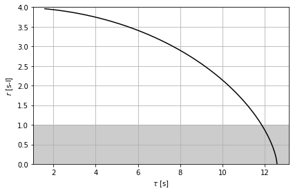

```python
# Propiedades
c=3e5 #km/s
RS=3e5 #km

#Punto de lanzamiento
r0=4*RS

#Valores de la coordenada radial
from numpy import linspace
rs=linspace(0,0.99*r0,1000)

#Valores del tiempo propio
from numpy import pi,sqrt,arctan
taus=(r0/RS)*sqrt(r0/RS)*(pi/2+sqrt((rs/r0)*(1-rs/r0))+arctan(-sqrt(rs/(r0-rs))))

#Gráfico
import matplotlib.pyplot as plt
fig=plt.figure()
ax=fig.gca()

ax.axhspan(0,1,color='k',alpha=0.2)
ax.plot(taus,rs/c,'k-')

#Decoracion
ax.set_ylim((0,r0/c))
ax.grid()
ax.set_xlabel(r"$\tau$ [s]")
ax.set_ylabel(r"$r$ [s-l]")

fig.tight_layout()
```

**Figura 1.9.**

Como podemos ver el tiempo para un observador en caída libre (el que registra el tiempo propio es finito.

¿Pero qué ve un observador remoto?. Habíamos demostrado que $\mathrm{d}t_\infty=\mathrm{d}t$. Una de las ecuaciones de movimiento nos da la manera como evoluciona el tiempo coordenado o el tiempo del observador remoto:

$$ \frac{E_\infty}{mc^2} = \left(1-\frac{R_S}{r}\right)\left(\frac{\mathrm{d} t_\infty}{\mathrm{d} \tau}\right) $$

Usando el valor obtenido para $E_\infty$ obtenemos la ecuación:

$$ \frac{\mathrm{d} t_\infty}{\mathrm{d} \tau}=\frac{\left(1-R_{\mathrm{S}} / r_{0}\right)^{1 / 2}}{1-R_{\mathrm{S}} / r} $$

Usando la ecuación para $\tau$ podemos escribir la ecuación diferencial para $t_\infty$:

$$ \frac{\mathrm{d} t_\infty}{\mathrm{d} r}=-\frac{1}{c R_{\mathrm{S}}^{1 / 2}} \frac{\left(1-R_{\mathrm{S}} / r_{0}\right)^{1 / 2}}{1-R_{\mathrm{S}} / r} \sqrt{\frac{r r_{0}}{r_{0}-r}} $$

Esta ecuación diferencial es suficientemente complicada para ameritar una integración numérica. En el código a continuación la realizamos la integración y hacemos un gráfico comparativo del tiempo de caída (medido por un observador externo) y el tiempo propio:

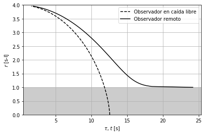

```python
integrando=lambda r:-(1/(c*RS**0.5))*(1-RS/r0)**0.5/(1-RS/r)*sqrt(r*r0/(r0-r))
from scipy.integrate import quad

#La integral la hacemos
rinfs=linspace(1.0001*RS,0.99*r0,100)
tinfs=[quad(integrando,r0,r)[0] for r in rinfs]

#Gráfico
import matplotlib.pyplot as plt
fig=plt.figure()
ax=fig.gca()

ax.axhspan(0,1,color='k',alpha=0.2)
ax.plot(taus,rs/c,'k--',label='Observador en caída libre')
ax.plot(tinfs,rinfs/c,'k-',label='Observador remoto')

#Decoracion
ax.set_ylim((0,r0/c))
ax.grid()
ax.legend()
ax.set_xlabel(r"$\tau$, $t$ [s]")
ax.set_ylabel(r"$r$ [s-l]")

fig.tight_layout()
```

**Figura 1.10.**

Es en este resultado (y no en otro) que estriba la verdadera naturaleza peculiar de los agujeros negros.

**Definición: Agujero negro**. Un **agujero negro** es un cuerpo que tiene un tamaño inferior a la escala natural de longitud gravitaciional $R_S$ y para el cuál una partícula con masa en caída libre radial tarda un tiempo finito en alcanzar la superficie del cuerpo, medido en el sistema de referencia del observador en caída libre, y un tiempo infinito para un observador remoto en reposo respecto al cuerpo, que además percibe que la partícula nunca atraviesa la superficie imaginaria $r=R_S$ que llamaremos el **horizonte de eventos.**

La pregunta importante aquí es: ¿cae o no cae la partícula en el agujero negro? La respuesta sin duda alguna es que depende del observador. No hay manera de decir algo que sea objetivamente cierto para todos los observadores. El destino de una partícula que cae en un agujero negro es relativa.

Ahora bien ¿qué pasa para puntos $r<R_S$. Ciertamente la métrica de Schwarzschild se hace inconveniente para responder esta pregunta porque el signo de los coeficientes métricos de la coordenada radial y temporal se invierten. Pero no hay que olvidar que estas son solo coordenadas, no cantidades observables.

Es en este punto en el que es necesario pensar en un cambio de coordenadas.

Indice | Previo: Aplicaciones.AgujerosNegros.FenomenologiaBasica | Siguiente: Aplicaciones.AgujerosNegros.Coordenadas